# Data Exploration

# Choosing out facets to take a look at (1,2)

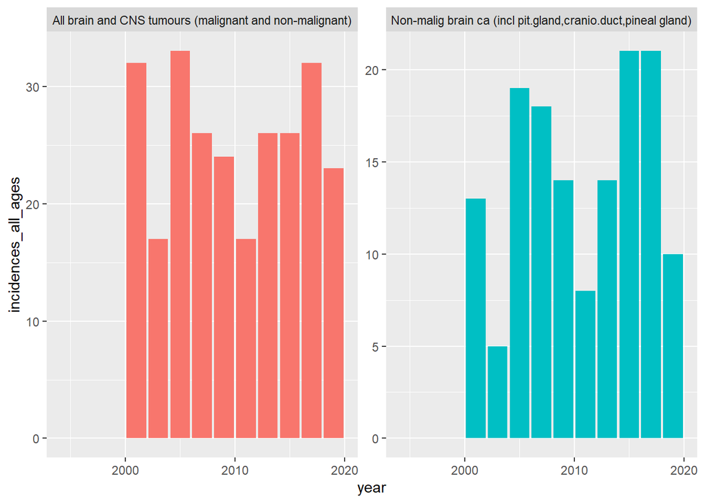

```r
incidence_clean %>%
  filter(health_board_name == "Borders") %>%
  filter(sex == "All") %>%
  filter(cancer_site == c("All brain and CNS tumours (malignant and non-malignant)", "Non-malig brain ca (incl pit.gland,cranio.duct,pineal gland)")) %>%
  ggplot() +
  aes(x = year, y = incidences_all_ages, fill = cancer_site) +
  geom_col() +
  theme(legend.position = "none") +
  facet_wrap(~ cancer_site, scales = "free")
```

# Top 3,4

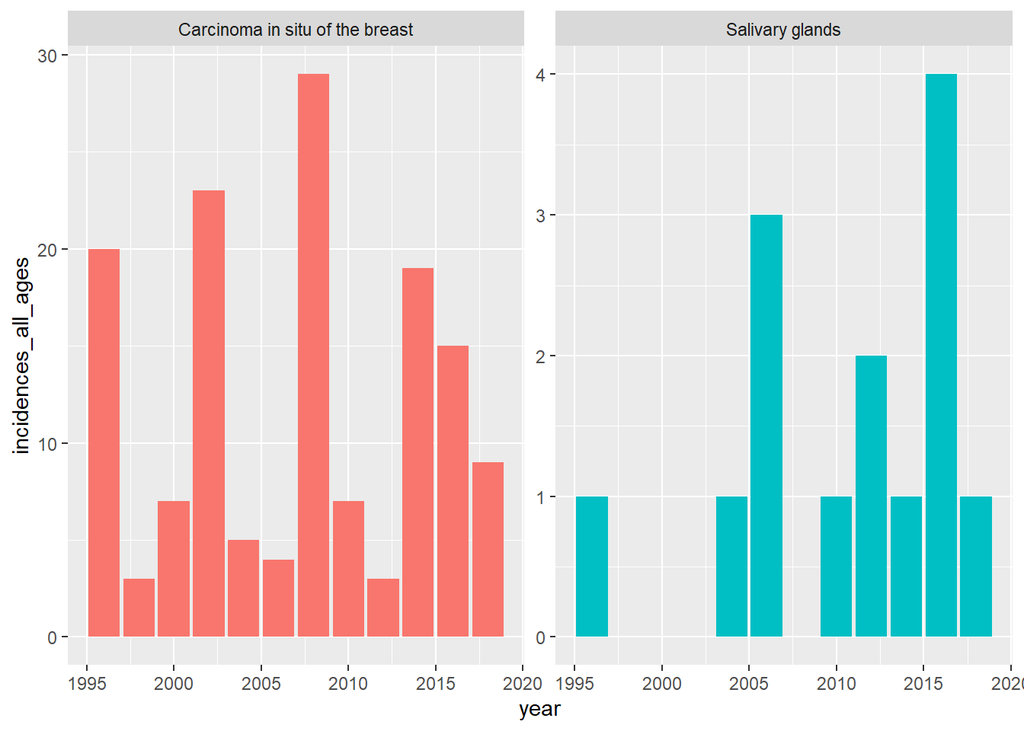

```r
incidence_clean %>%
  filter(health_board_name == "Borders") %>%
  filter(sex == "All") %>%
  filter(cancer_site == c("Salivary glands", "Carcinoma in situ of the breast")) %>%
  ggplot() +
  aes(x = year, y = incidences_all_ages, fill = cancer_site) +
  geom_col() +
  theme(legend.position = "none") +
  facet_wrap(~ cancer_site, scales = "free")
```

# 5,6

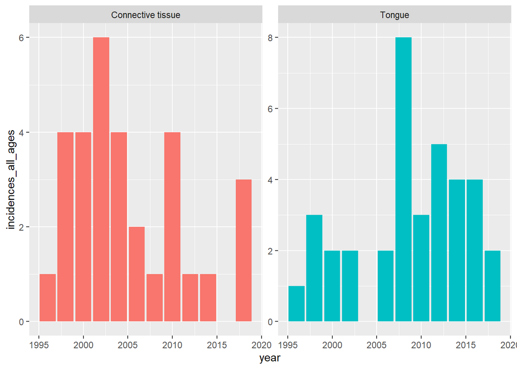

```r
incidence_clean %>%
  filter(health_board_name == "Borders") %>%
  filter(sex == "All") %>%
  filter(cancer_site == c("Tongue", "Connective tissue")) %>%
  ggplot() +
  aes(x = year, y = incidences_all_ages, fill = cancer_site) +
  geom_col() +
  theme(legend.position = "none") +
  facet_wrap(~ cancer_site, scales = "free")
```

# 7,8

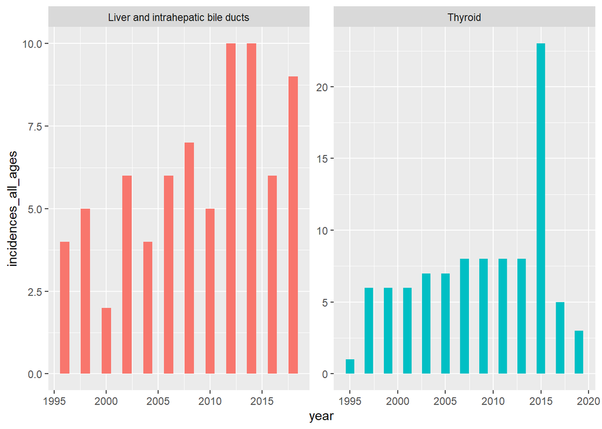

```r
# "Liver and intrahepatic bile ducts"

incidence_clean %>%
  filter(health_board_name == "Borders") %>%
  filter(sex == "All") %>%
  filter(cancer_site == c("Thyroid", "Liver and intrahepatic bile ducts")) %>%
  ggplot() +
  aes(x = year, y = incidences_all_ages, fill = cancer_site) +
  geom_col() +
  theme(legend.position = "none") +
  facet_wrap(~ cancer_site, scales = "free")
```

```r
# Liver is trending up
```

# 9,10

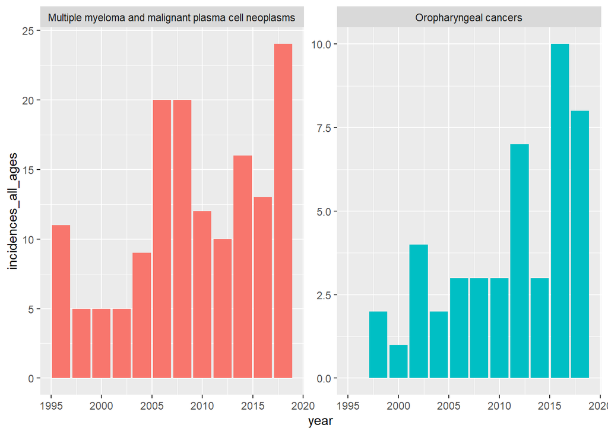

```r
# "Multiple myeloma and malignant plasma cell neoplasms", "Oropharyngeal cancers"

incidence_clean %>%
  filter(health_board_name == "Borders") %>%
  filter(sex == "All") %>%
  filter(cancer_site == c("Multiple myeloma and malignant plasma cell neoplasms", "Oropharyngeal cancers")) %>%
  ggplot() +
  aes(x = year, y = incidences_all_ages, fill = cancer_site) +
  geom_col() +
  theme(legend.position = "none") +
  facet_wrap(~ cancer_site, scales = "free")
```

# 11,12

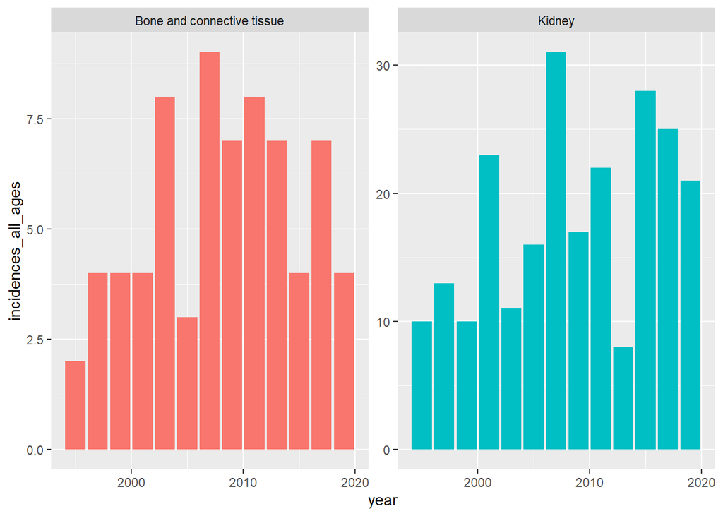

```r
# Kidney

incidence_clean %>%
  filter(health_board_name == "Borders") %>%
  filter(sex == "All") %>%
  filter(cancer_site == c("Kidney", "Bone and connective tissue")) %>%
  ggplot() +
  aes(x = year, y = incidences_all_ages, fill = cancer_site) +
  geom_col() +
  theme(legend.position = "none") +
  facet_wrap(~ cancer_site, scales = "free")
```

# 13,14

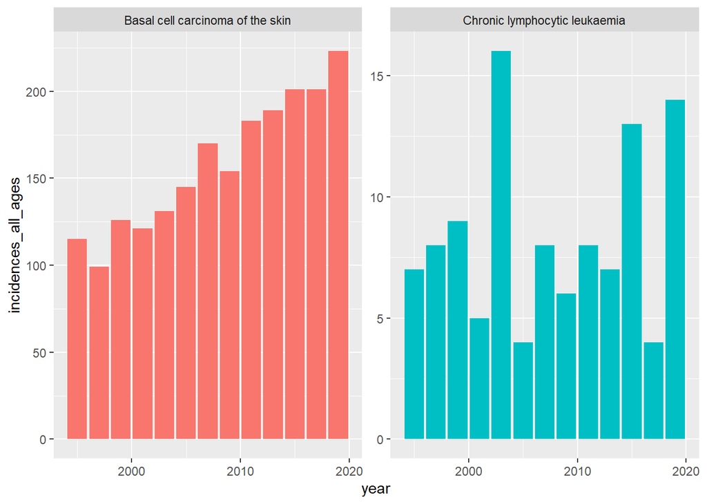

```r
# Basal cell carcinoma of the skin

incidence_clean %>%
  filter(health_board_name == "Borders") %>%
  filter(sex == "All") %>%
  filter(cancer_site == c("Chronic lymphocytic leukaemia", "Basal cell carcinoma of the skin")) %>%
  ggplot() +
  aes(x = year, y = incidences_all_ages, fill = cancer_site) +
  geom_col() +
  theme(legend.position = "none") +
  facet_wrap(~ cancer_site, scales = "free")
```

# 15,16

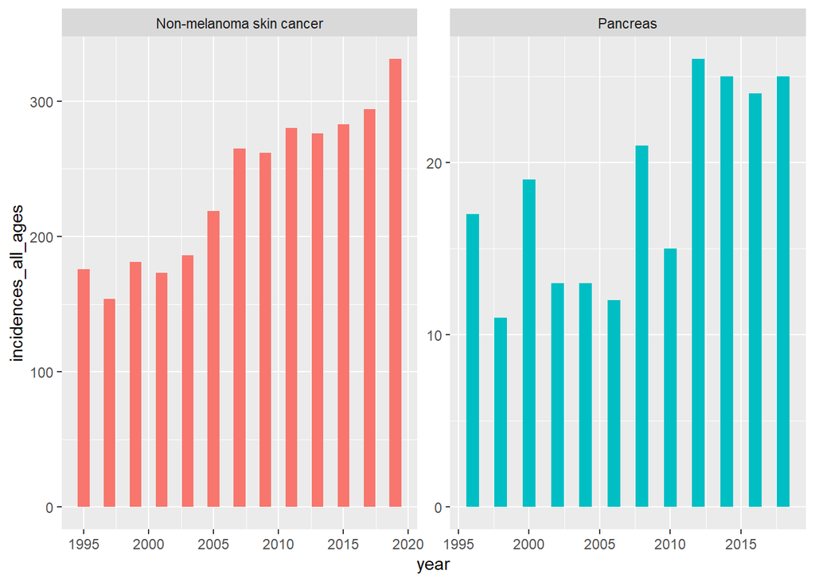

```r
# "Non-melanoma skin cancer", "Pancreas"

incidence_clean %>%
  filter(health_board_name == "Borders") %>%
  filter(sex == "All") %>%
  filter(cancer_site == c("Non-melanoma skin cancer", "Pancreas")) %>%
  ggplot() +
  aes(x = year, y = incidences_all_ages, fill = cancer_site) +
  geom_col() +
  theme(legend.position = "none") +
  facet_wrap(~ cancer_site, scales = "free")
```

# 17,18

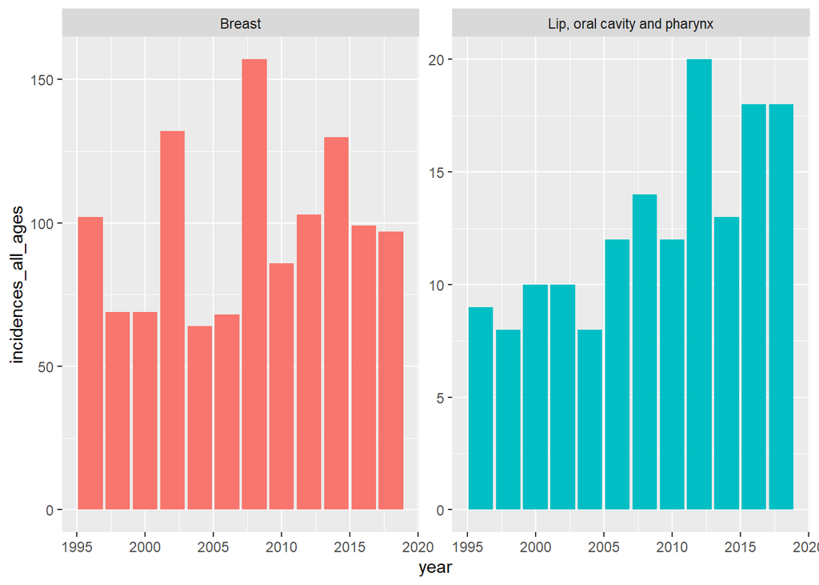

```r
# Lip, oral cavity and pharynx

incidence_clean %>%
  filter(health_board_name == "Borders") %>%
  filter(sex == "All") %>%
  filter(cancer_site == c("Breast", "Lip, oral cavity and pharynx")) %>%
  ggplot() +
  aes(x = year, y = incidences_all_ages, fill = cancer_site) +
  geom_col() +
  theme(legend.position = "none") +
  facet_wrap(~ cancer_site, scales = "free")
```

# 19, 20

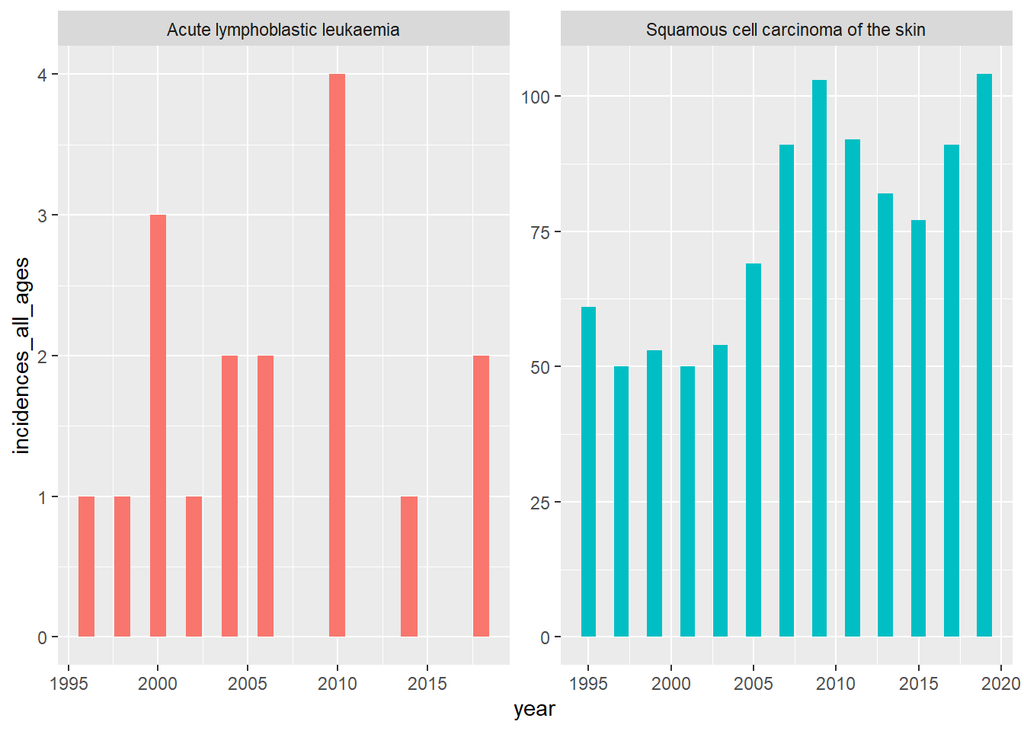

```r
# Squamous cell carcinoma of the skin

incidence_clean %>%
  filter(health_board_name == "Borders") %>%
  filter(sex == "All") %>%
  filter(cancer_site == c("Squamous cell carcinoma of the skin", "Acute lymphoblastic leukaemia")) %>%
  ggplot() +
  aes(x = year, y = incidences_all_ages, fill = cancer_site) +
  geom_col() +
  theme(legend.position = "none") +
  facet_wrap(~ cancer_site, scales = "free")
```

# From all 20 graphs I was able to pick out 9 cancer sites which showed consistent trend increases in incidences in the Borders. Moving forward, it would be preferable to do a linear regression to obtain the gradient, which would inform the expected rate increase that NHS Borders could expect year on year - for each group of cancer

# This could be very helpful to supply chain teams within hospitals who need to provision the treatments for these types of cancer.

# It would also inform hospital management and specialists on how they would be able to manage say, increased chemotherapy, for these expected patients.

# This could inform NHS Borders public health policy and messaging. There may be increased cancer awareness and early detection targeting these cancer types - informed by specialists and consultants - with what to look out for.

# Future - could use the age range statistics to inform what ages and sexs need targeting for messaging

# Breakdowns of Borders vs. Scotland vs. Europe